# Befolkningsutvecklingen i Gagnef

Befolkningsutvecklingen i Gagnef  
- en kort analys

Rapporten är skapad av Samhällsanalys, Region Dalarna  
Senast uppdaterad: 2025-02-27

# Sammanfattning

Syftet med den här korta analysen är att undersöka Gagnefs befolkningsutveckling. Ett antal viktiga slutsatser sammanfattas här:

För mer info om statistiken, klicka på rutan nedan:

**Mer information om statistiken**

I folkmängden som SCB publicerar ingår personer som är folkbokförda i landet. För att den som flyttar till Sverige ska bli folkbokförd ska personen ha för avsikt och rätt att stanna i Sverige i minst ett år. För personer som inte är medborgare i ett EU-land innebär det att det krävs ett uppehållstillstånd som gäller minst 12 månader för att bli folkbokförd. Till följd av Rysslands invasion av Ukraina den 24 februari 2022 har Europeiska unionen (EU) beslutat att aktivera massflyktsdirektivet, vilket innebär att personer från Ukraina utan individuell prövning ska erbjudas tidsbegränsat uppehålls- och arbetstillstånd inom EU. Personer som får uppehållstillstånd enligt massflyktsdirektivet ska i regel inte bli folkbokförda och ingå i den officiella befolkningsstatistiken. Läs mer här. Sedan juni 2024 har dock personer födda i Ukraina haft möjlighet att ansöka om att bli folkbokförda i Sverige [(SCB)](https://www.scb.se/hitta-statistik/statistik-efter-amne/befolkning-och-levnadsforhallanden/befolkningens-sammansattning-och-utveckling/befolkningsstatistik/pong/statistiknyhet/namnlos/).

Under 2023 inledde Skatteverket ett arbete med att granska registret över folkbokförda. Det förde med sig att SCB avregistrerade flera tusen folkbokförda personer som visade sig inte längre bo i Sverige. I folkbokföringen har dessa registrerats som utvandrade till okänt utvandringsland. Detta arbete fortsatte under 2024. Läs mer [här](https://www.scb.se/pressmeddelande/sverige-gar-mot-lagsta-befolkningsokningen-pa-manga-ar/).

All data som används i rapporten är offentlig och finns under kategorin befolkning i SCB:s [Statistikdatabas](https://www.statistikdatabasen.scb.se/pxweb/sv/ssd/). Där finns även data för exempelvis befolkningsutvecklingen under 2025 på månadsbasis som publiceras löpande, något som inte behandlas i denna rapport.

# 1 Hur har befolkningen förändrats?

En viktig orsak till Gagnef positiva befolkningstillväxt på längre sikt är troligtvis närheten till större städer som Borlänge och Falun. Arbetsmarknaden för personer boende i Gagnef blir därför större än vad den annars skulle vara, vilket gör kommunen mer attraktiv att bo i.

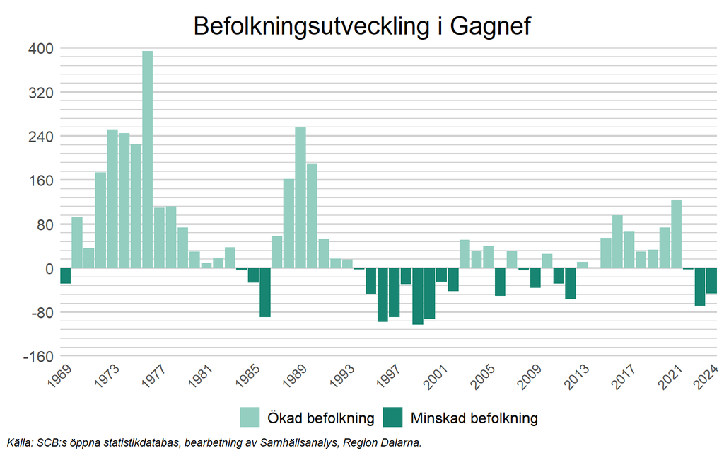

I fortsättningen av denna korta analys delas befolkningsutveckling upp i dess komponenter, födelsenetto, dvs. nettot av födda och döda, och flyttnetto, dvs. nettot av inrikes och utrikes flyttar.

# 2 Födelsenetto

Med undantag för Corona-pandemin (2020) är en trend att det dör något färre personer i Gagnef idag än det gjorde längre tillbaka i tiden. På senare år har ofta under 100 personer dött årligen i kommunen, att jämföra med en bit över 100 per år under exempelvis 1970-talet. Denna utveckling härrör sannolikt till utveckling inom det medicinska området. Befolkningens medelålder ökar över tid och har gjort så länge. Antalet avlidna ökade dock något under 2024.

När det gäller antalet födslar har Gagnef länge skiljt sig från de flesta andra kommuner i Dalarna, då utvecklingen sedan slutet av 1960-talet har varit positiv. Under 2024 föddes dock ovanligt få barn i kommunen (det lägsta antalet sedan 1969) och kommunen gick från att ha högst fruktsamhet bland Dalarnas kommuner 2023 till lägst 2024 (se rapporten för Dalarnas län). Exakt vad detta beror på är svårt att sia om, men Gagnef är en relativt liten kommun och variationen kan därför vara stor mellan åren.

Nettot mellan födda och döda, se de svarta linjerna i diagrammet nedan, varierar relativt mycket mellan åren, men har under 2010-talet och åren därefter mestadels varit positiv. År 2024 medförde dock de ovanligt låga födelsetalen att befolkningen minskade 35 personer till följd av ett negativt födelsenetto, vilket var en tydlig förändring jämfört med åren innan när födelsenettot var positivt.

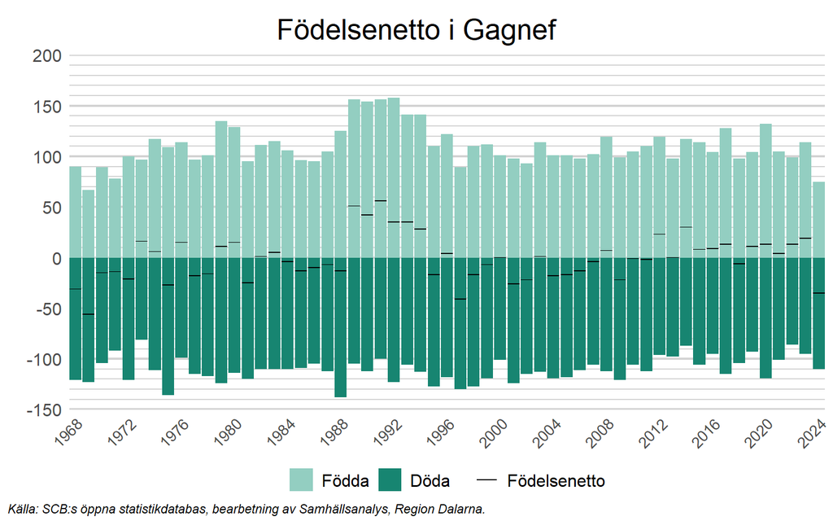

# 3 Flyttnetto

Den andra komponenten som styr befolkningsutvecklingen är det så kallade flyttnettot. Detta kan i sin tur delas upp i två komponenter, inrikes och utrikes flyttar. I det här avsnittet är fokus först på flyttnettot, innan de två komponenterna undersöks.

Nettot mellan antalet personer som flyttar till och från Gagnef, som varierar relativt mycket mellan åren, har varit positivt under stora delar av 2010-talet. Många flyttade till kommunen i mitten på 2010-talet, men även under 2020 och 2021 var inflyttningen stor (netto). På senare år har flyttnettot dock varit negativt. År 2024 minskade befolkningen i Gagnef med 9 personer på grund av ett negativt flyttnetto. Detta var dock en tydligt lägre minskning än året innan.

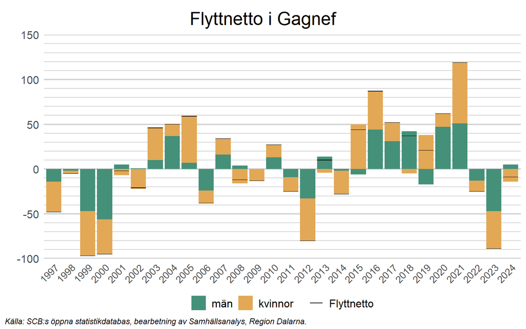

## 3.1 Utrikes flyttnetto

Som berördes i föregående avsnitt, flyttade många till Gagnef i mitten på 2010-talet, vilket till stor del kan förklaras av att invandringen då var stor. I slutet av 1990-talet var invandringen ofta väldigt låg och till och med negativ under vissa år (fler utvandrade än invandrade), men därefter skedde en gradvis ökning innan den stora toppen 2017. Därefter minskade invandringen tydligt, vilket sannolikt har att göra med en stramare nationell migrationspolitik. Med undantag för pandemiåret 2020, och 2023, har dock invandringen legat på relativt höga nivåer.

Efter att ha varit negativt år 2023, ökade invandringsöverskottet tydligt under 2024 till 26 personer, det högsta nettot sedan 2019. Att nettot ökade jämfört med året innan kan delvis förklaras med att personer födda i Ukraina sedan juni 2024 haft möjlighet att ansöka om att bli folkbokförda i Sverige, vilket medförde att antalet personer födda i Ukraina ökade med drygt 20 personer i Gagnef under 2024 (se [SCB](https://www.statistikdatabasen.scb.se/pxweb/sv/ssd/START__BE__BE0101__BE0101E/FolkmRegFlandK/table/tableViewLayout1/)). Läs mer i den klickbara rutan “mer information om statistiken” ovan.

Värt att notera är även att de avregistreringar av utvandrade som Skattemyndigheten påbörjade under 2023 (se informationsrutan under avsnittet introduktion ovan) får en påverkan på utvandringen under såväl 2023 som 2024.

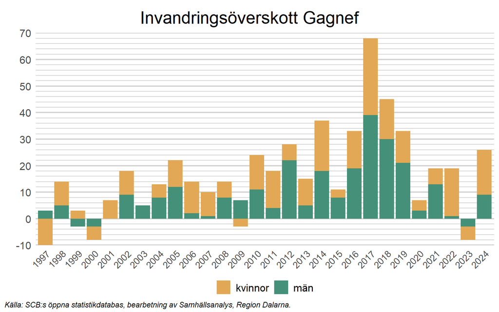

## 3.2 Inrikes flyttnetto

Det inrikes flyttnettot varierar förhållandevis mycket mellan åren i Gagnef, med omväxlande perioder av positivt och negativt flyttnetto. Under åren runt Corona-pandemin (2020-2021) var nettot tydligt positivt, då befolkningen ökade med mer än 150 personer till följd av inrikes flyttar. De senaste åren har utveckling återigen vänt och fler personer flyttar från än till kommunen inrikes. År 2024 flyttade 35 personer netto från kommunen inrikes, vilket var färre än åren innan.

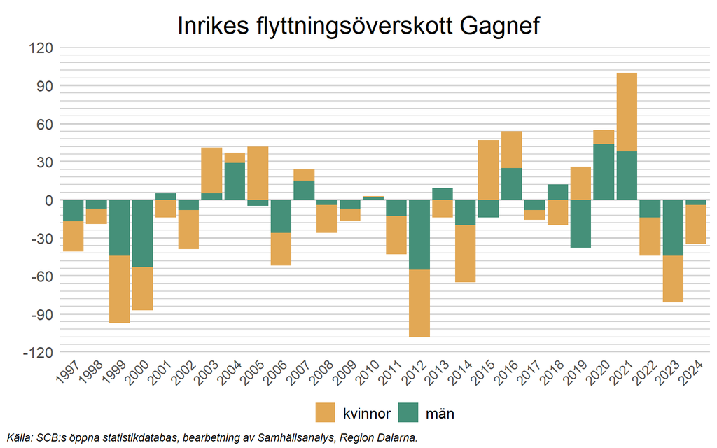

För att bättre förstå vilka som flyttar till och från Gagnef inrikes, delas de som flyttar härnäst upp efter ålder. Normalt är personer mest benägna att flytta till en annan ort när de är i 20-års åldern, innan flyttandet gradvis avtar.

### 3.2.1 Uppdelat på ålder

Ett mönster är att det till Gagnef flyttar fler personer mellan 30 och 39 år än de i samma åldersgrupp som flyttar därifrån, dvs. kommunens invånarantal i den åldersgruppen ökar på grund av inrikes flyttar. Variationen är dock relativ stor mellan åren.

Bland de åldersgrupper som redovisas i diagrammet nedan skedde den största utflyttningen (netto) år 2024 i gruppen som är 20-29 år, vilket dock var en tydligt lägre utflyttning än året innan. I denna grupp, tillsammans med de som är under 20 år, var antalet uflyttare 30 fler än antalet inflyttare. Värt att notera är dock att det även i åldersgruppen 0-19 år var en klart lägre utflyttning under 2024 (netto) än året innan.

Inom övriga åldergrupper är variationen stor mellan åren och det är svårt att hitta någon större trend, även om många över 60 år flyttade från kommunen under 2024.

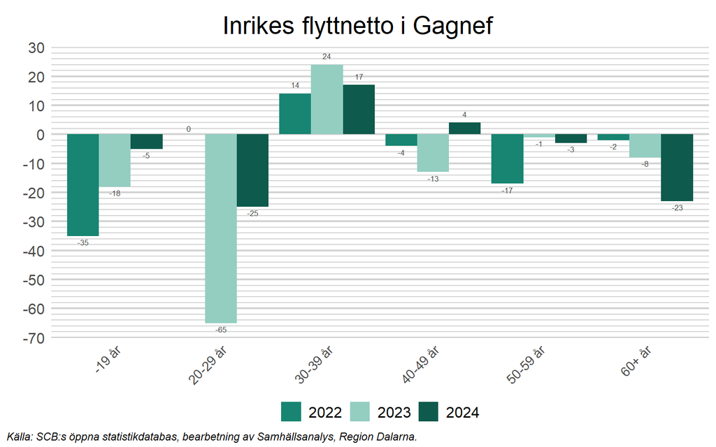

Om fokus enbart läggs på åldersgruppen 20-29 år, blir det tydligt att det under de flesta år flyttar fler unga vuxna från än till kommunen inrikes. Historiskt varierar det inrikes flyttnettot i åldersgruppen mellan åren, vilket exempelvis kan bero på att olika årskullar av barn är olika stora. Under 2024 flyttade 25 personer netto från kommunen inrikes, vilket var en lägre utflyttning än året innan.

Även i Dalarna som helhet flyttade fler i åldersgruppen ut än in under 2024.

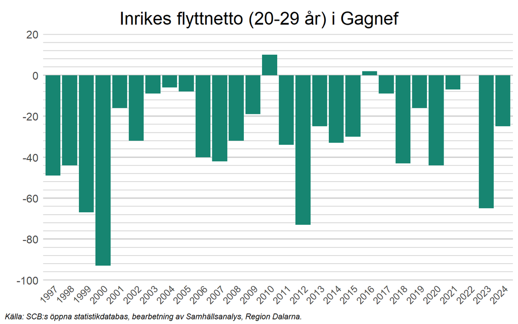

### 3.2.2 Uppdelat på bakgrund

*Observera att statistik i detta avsnitt uppdateras först i slutet av mars.*

För att ytterligare förtydliga vilka som flyttar till och från Gagnef inrikes, delas de i detta avsnitt upp efter sin bakgrund, inrikes eller utrikes födda.

En del av de personer som invandrade till Gagnef under framförallt 2017, verkar ha flyttat därifrån sedan dess, då det inrikes flyttnettot i gruppen utrikes födda har varit negativt under varje år sedan 2019.

Bland inrikes födda är variationen mellan åren stor, men tydligt är att relativt många inrikes födda flyttade till kommunen i samband med Corona-pandemin (2020-2021). De senaste åren har utvecklingen dock varit det motsatta, då fler personer födda i Sverige flyttar från än till kommunen inrikes. Det inrikes flyttnettot i gruppen var -43 år 2023.

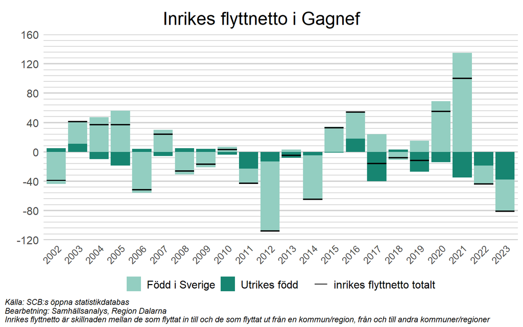

I nästa avsnitt är fokus istället på framtiden. Hur kommer Gagnefs folkmängd att utvecklas fram till 2033?

# 4 Vad händer i framtiden?

För en djupare förståelse runt hur SCB gör befolkningsprognoser, se motsvarande avsnitt i rapporten för hela Dalarnas län. Det viktigaste att ha i åtanke är att ingen hänsyn tas i prognoserna till planerat bostadsbyggande, företagsetableringar eller andra framtida mål och förutsättningar som kommunerna har i sina planer.

I diagrammet nedan visas befolkningsutvecklingen i Gagnef fram till 2033 uppdelat på åldersgrupper, enligt SCB:s prognos från juni 2024 (se [SCB, 2024](https://www.statistikdatabasen.scb.se/pxweb/sv/ssd/START__BE__BE0401__BE0401A/BefProgRegFakN/)), vilket är den senaste som myndigheten publicerat offentligt på kommunal nivå. Notera att diagrammet kan skilja sig åt jämfört med motsvarande diagram i förra årets rapport. Detta eftersom befolkningen 2033 enligt SCBs prognos jämförs med den faktiska befolkningen vid slutet av 2024 i diagrammet nedan. I förra årets rapport jämfördes prognosen för 2033 med den faktiska befolkningen vid slutet av 2023.

- Gagnefs befolkning prognostiseras att vara mer eller mindre oförändrad år 2033, jämfört med år 2024. I SCB:s föregående prognos, som släpptes 2022, prognostiserades en ökning på ungefär 240 personer fram till 2033, jämfört med 2021 (se [SCB, 2022](https://www.statistikdatabasen.scb.se/pxweb/sv/ssd/START__BE__BE0401__BE0401B/BefProgRegFakN22/table/tableViewLayout1/)) fram till 2033.
- Den största minskningen sker i åldersgruppen 20-64 år, som prognostiseras minska med ungefär 180 personer.
- I åldergruppen 80+ förväntas befolkning istället att öka med ungefär 320 personer fram till 2033. Detta hänger sannolikt samman med att den förväntade livslängden fortsätter öka och att den stora gruppen “baby-boomers” börjar komma upp i 80-års åldern.
- Även i åldersgruppen 65-79 år prognostiseras en relativt stor minskning av befolkningen, ca 80 personer.

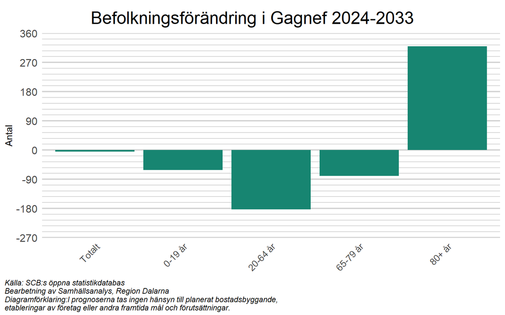